## **Input: Region-Level Summary Data**

Completed on: Wed Aug 30 18:07:23 2023 (Asia/Shanghai), with the runtime of (3 seconds).

| Input GR | Chromosome | Length | Pvalue |
| --- | --- | --- | --- |
| chr20:4090134-4092134 | chr20 | 2001 | 6e-19 |
| chr11:117973237-117975237 | chr11 | 2001 | 3.4e-18 |
| chr1:212634309-212636309 | chr1 | 2001 | 2.2e-17 |
| chr1:212635821-212637821 | chr1 | 2001 | 5.2e-17 |
| chr20:4081996-4083996 | chr20 | 2001 | 1.6e-15 |
| chr17:36127082-36129082 | chr17 | 2001 | 1.6e-15 |
| chr17:36143118-36145118 | chr17 | 2001 | 1.6e-15 |
| chr17:36132988-36134988 | chr17 | 2001 | 5.2e-15 |
| chr1:212637708-212639708 | chr1 | 2001 | 1.7e-14 |
| chr2:113097209-113099209 | chr2 | 2001 | 2.3e-14 |

[output cut: 666 more lines]

## **Output: Linked Genes**

> **Linked Gene table** contains information on genes (n=786, linked from the input genomic regions), including the column `GScores` (ranged from 1 to 10) that quantifies the degree to which genes are likely modulated by input genomic regions. Please refer to **`Evidence table`** for details on the linking evidence.

| Linked genes | GScores | Description |
| --- | --- | --- |
| Dnah17 | 10 | dynein, axonemal, heavy chain 17 |
| Mir6933 | 10 | microRNA 6933 |
| Pgs1 | 10 | phosphatidylglycerophosphate synthase 1 |
| Socs3 | 10 | suppressor of cytokine signaling 3 |
| 2410017I17Rik | 8.632 | RIKEN cDNA 2410017I17 gene |
| BC023719 | 8.632 | cDNA sequence BC023719 |
| Gm10499 | 8.632 | predicted gene 10499 |
| Gm17782 | 8.632 | predicted gene, 17782 |
| Gm19684 | 8.632 | predicted gene, 19684 |
| Gm6659 | 8.632 | predicted gene 6659 |

[output cut: 776 more lines]

> **Evidence table** displays information about the genomic regions (listed under the column `GR`) that overlap the input genomic regions (listed under the column `Input GR`). The overlapped regions are used to define linked genes (listed under the column `Linked genes`) based on the evidence provided (see the column `Evidence`). The column `Evidence` indicates the datasets used, such as `Proximity` for genomic regions in proximity, and the prefix `EP_` for enhancer-promoter datasets.

| Input GR | GR | Linked genes | Evidence |
| --- | --- | --- | --- |
| chr11:117973237-117975237 | chr11:117973237-117975237 | Dnah17 | Proximity_50000bp |
| chr11:117973237-117975237 | chr11:117973237-117975237 | Dnah17 | Proximity_50000bp |
| chr11:117973237-117975237 | chr11:117973237-117975237 | Dnah17 | Proximity_50000bp |
| chr11:117973237-117975237 | chr11:117973237-117975237 | Dnah17 | Proximity_50000bp |
| chr11:117973237-117975237 | chr11:117973237-117975237 | Mir6933 | Proximity_50000bp |
| chr11:117973237-117975237 | chr11:117973237-117975237 | Mir6933 | Proximity_50000bp |
| chr11:117973237-117975237 | chr11:117973237-117975237 | Mir6933 | Proximity_50000bp |
| chr11:117973237-117975237 | chr11:117973237-117975237 | Mir6933 | Proximity_50000bp |
| chr11:117973237-117975237 | chr11:117973237-117975237 | Pgs1 | Proximity_50000bp |
| chr11:117973237-117975237 | chr11:117973237-117975237 | Pgs1 | Proximity_50000bp |

[output cut: 6770 more lines]

## **Output: Gene Subnetwork**

> **A network visualisation** of the subnetwork, with 32 genes/nodes color-coded by linked gene scores (ranged from 1 to 10). An editable pdf file is also available for download.

DOWNLOAD .pdf

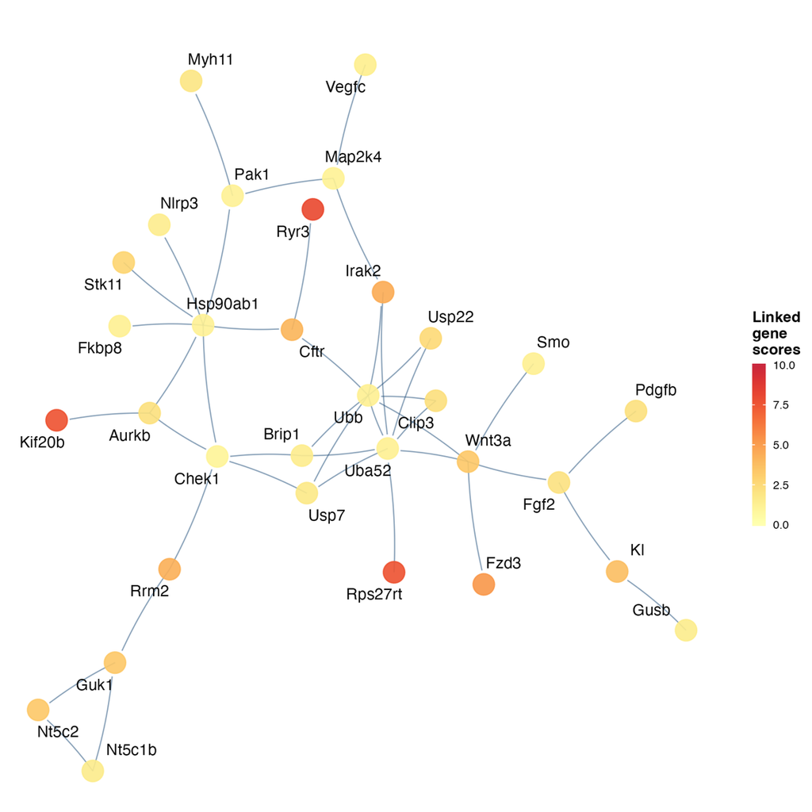

Figure 1: Visualisation of the subnetwork, with genes/nodes color-coded by linked gene scores (ranged from 1 to 10).

> **An interactive table** for the subnetwork genes (n=32), with the column `GScores` for linked gene scores (ranged from 1 to 10).

| Linked genes | GScores | Description |
| --- | --- | --- |
| Ryr3 | 8.024 | ryanodine receptor 3 |
| Rps27rt | 7.594 | ribosomal protein S27, retrogene |
| Kif20b | 7.594 | kinesin family member 20B |
| Fzd3 | 5.181 | frizzled class receptor 3 |
| Irak2 | 4.5 | interleukin-1 receptor-associated kinase 2 |
| Rrm2 | 4.339 | ribonucleotide reductase M2 |
| Cftr | 4.107 | cystic fibrosis transmembrane conductance regulator |
| Kl | 3.759 | klotho |
| Nt5c2 | 3.404 | 5'-nucleotidase, cytosolic II |
| Wnt3a | 3.38 | wingless-type MMTV integration site family, member 3A |

[output cut: 22 more lines]